# IS 670 Lab 3: Decision Tree

This data set contains information of cars purchased at the Auction.  
We will use this file to predict the quality of buying decisions and visualize decision processes.  
VARIABLE DESCRIPTIONS:  
Auction: Auction provider at which the vehicle was purchased  
Color: Vehicle Color  
IsBadBuy: Identifies if the kicked vehicle was an avoidable purchase  
MMRCurrentAuctionAveragePrice: Acquisition price for this vehicle in average condition as of current day  
Size: The size category of the vehicle (Compact, SUV, etc.)  
TopThreeAmericanName:Identifies if the manufacturer is one of the top three American manufacturers  
VehBCost: Acquisition cost paid for the vehicle at time of purchase  
VehicleAge: The Years elapsed since the manufacturer's year  
VehOdo: The vehicles odometer reading  
WarrantyCost: Warranty price (term=36month and millage=36K)  
WheelType: The vehicle wheel type description (Alloy, Covers)  
Target variable: **IsBadBuy**

### 1. Upload and clean data

```python
# Mounting Google Drive
from google.colab import drive
drive.mount('/content/drive')
```

```python
# Import libraries
import pandas as pd
from sklearn.model_selection import train_test_split
from matplotlib import pyplot as plt
from sklearn import tree
from sklearn.tree import DecisionTreeClassifier
from sklearn.metrics import confusion_matrix
from sklearn.metrics import ConfusionMatrixDisplay
from sklearn.metrics import classification_report
from sklearn.metrics import roc_curve, roc_auc_score
```

```python
# Read data
car_kick = pd.read_csv("/content/drive/MyDrive/IS 670/car_kick.csv")
car_kick
```

|  | PurchDate | VehYear | VehicleAge | VehOdo | MMRAcquisitionAuctionAveragePrice | MMRAcquisitionAuctionCleanPrice | MMRAcquisitionRetailAveragePrice | MMRAcquisitonRetailCleanPrice | MMRCurrentAuctionAveragePrice | MMRCurrentAuctionCleanPrice | ... | WheelTypeID | WheelType | Nationality | Size | TopThreeAmericanName | BYRNO | VNZIP1 | VNST | IsOnlineSale | IsBadBuy |
| --- | --- | --- | --- | --- | --- | --- | --- | --- | --- | --- | --- | --- | --- | --- | --- | --- | --- | --- | --- | --- | --- |
| 0 | 1289952000 | 2006 | 4 | 51954 | 6197 | 7062 | 9605 | 10426 | 5341 | 6351 | ... | 2 | Covers | AMERICAN | MEDIUM | CHRYSLER | 99750 | 32124 | FL | 0 | 0 |
| 1 | 1242691200 | 2005 | 4 | 89127 | 3688 | 4783 | 4483 | 5666 | 3688 | 4783 | ... | 2 | Covers | AMERICAN | MEDIUM | FORD | 20833 | 78754 | TX | 0 | 0 |
| 2 | 1248220800 | 2006 | 3 | 71271 | 6897 | 8449 | 7949 | 9625 | 6868 | 8549 | ... | 1 | Alloy | AMERICAN | LARGE | GM | 22916 | 80011 | CO | 0 | 0 |
| 3 | 1285718400 | 2008 | 2 | 83338 | 7878 | 8925 | 11723 | 13026 | 7801 | 8704 | ... | 2 | Covers | AMERICAN | LARGE | GM | 23657 | 94544 | CA | 0 | 0 |
| 4 | 1237334400 | 2007 | 2 | 58698 | 8800 | 10091 | 10004 | 11398 | 7355 | 8543 | ... | 1 | Alloy | AMERICAN | LARGE | GM | 20833 | 77086 | TX | 0 | 0 |
| ... | ... | ... | ... | ... | ... | ... | ... | ... | ... | ... | ... | ... | ... | ... | ... | ... | ... | ... | ... | ... | ... |
| 67206 | 1285804800 | 2008 | 2 | 56072 | 6255 | 6972 | 9852 | 10567 | 6326 | 7126 | ... | 2 | Covers | AMERICAN | MEDIUM | CHRYSLER | 22808 | 77061 | TX | 0 | 1 |
| 67207 | 1274918400 | 2004 | 6 | 94232 | 8359 | 9645 | 12042 | 13302 | 7505 | 8188 | ... | 1 | Alloy | 'TOP LINE ASIAN' | 'MEDIUM SUV' | OTHER | 17675 | 28273 | NC | 0 | 1 |
| 67208 | 1280448000 | 2004 | 6 | 79534 | 2805 | 3826 | 6132 | 6871 | 3106 | 4479 | ... | 1 | Alloy | AMERICAN | MEDIUM | GM | 18880 | 37771 | TN | 0 | 1 |
| 67209 | 1285200000 | 2003 | 7 | 79394 | 4042 | 5296 | 7335 | 8983 | 3534 | 4732 | ... | 2 | Covers | AMERICAN | 'MEDIUM SUV' | GM | 23657 | 92337 | CA | 0 | 1 |
| 67210 | 1288742400 | 2004 | 6 | 94491 | 5194 | 6424 | 8532 | 9941 | 4417 | 5807 | ... | 1 | Alloy | 'OTHER ASIAN' | MEDIUM | OTHER | 835 | 87105 | NM | 0 | 1 |

67211 rows × 31 columns

```python
car_kick.keys()
```

```
Index(['PurchDate', 'VehYear', 'VehicleAge', 'VehOdo',
       'MMRAcquisitionAuctionAveragePrice', 'MMRAcquisitionAuctionCleanPrice',
       'MMRAcquisitionRetailAveragePrice', 'MMRAcquisitonRetailCleanPrice',
       'MMRCurrentAuctionAveragePrice', 'MMRCurrentAuctionCleanPrice',
       'MMRCurrentRetailAveragePrice', 'MMRCurrentRetailCleanPrice',
       'VehBCost', 'WarrantyCost', 'Auction', 'Make', 'Model', 'Trim',
       'SubModel', 'Color', 'Transmission', 'WheelTypeID', 'WheelType',
       'Nationality', 'Size', 'TopThreeAmericanName', 'BYRNO', 'VNZIP1',
       'VNST', 'IsOnlineSale', 'IsBadBuy'],
      dtype='object')
```

```python
# We select only a few columns here (for simplicity)
# In practice all of these columns must be explored and studied as part of our data understanding
desired_columns = ['Auction', 'Color', 'IsBadBuy', 'MMRCurrentAuctionAveragePrice', 'Size','TopThreeAmericanName',
'VehBCost', 'VehicleAge', 'VehOdo', 'WarrantyCost', 'WheelType']
car_kick_desired = car_kick [desired_columns]
```

```python
# Replacing 1 with Yes and 0 with No in the target column IsBadBuy
carAuction = car_kick_desired.copy() #why?
carAuction['IsBadBuy'] = carAuction['IsBadBuy'].replace({0: 'No', 1: 'Yes'})
```

```python
carAuction
```

|  | Auction | Color | IsBadBuy | MMRCurrentAuctionAveragePrice | Size | TopThreeAmericanName | VehBCost | VehicleAge | VehOdo | WarrantyCost | WheelType |
| --- | --- | --- | --- | --- | --- | --- | --- | --- | --- | --- | --- |
| 0 | MANHEIM | SILVER | No | 5341 | MEDIUM | CHRYSLER | 6500 | 4 | 51954 | 1086 | Covers |
| 1 | ADESA | SILVER | No | 3688 | MEDIUM | FORD | 3680 | 4 | 89127 | 983 | Covers |
| 2 | MANHEIM | RED | No | 6868 | LARGE | GM | 7170 | 3 | 71271 | 1974 | Alloy |
| 3 | MANHEIM | BLACK | No | 7801 | LARGE | GM | 7670 | 2 | 83338 | 2152 | Covers |
| 4 | ADESA | WHITE | No | 7355 | LARGE | GM | 7165 | 2 | 58698 | 1500 | Alloy |
| ... | ... | ... | ... | ... | ... | ... | ... | ... | ... | ... | ... |
| 67206 | MANHEIM | RED | Yes | 6326 | MEDIUM | CHRYSLER | 6680 | 2 | 56072 | 1086 | Covers |
| 67207 | ADESA | BLACK | Yes | 7505 | 'MEDIUM SUV' | OTHER | 8265 | 6 | 94232 | 909 | Alloy |
| 67208 | ADESA | GOLD | Yes | 3106 | MEDIUM | GM | 4950 | 6 | 79534 | 1506 | Alloy |
| 67209 | MANHEIM | WHITE | Yes | 3534 | 'MEDIUM SUV' | GM | 5220 | 7 | 79394 | 3967 | Covers |
| 67210 | MANHEIM | RED | Yes | 4417 | MEDIUM | OTHER | 5890 | 6 | 94491 | 1774 | Alloy |

67211 rows × 11 columns

```python
# Examine missing values again
carAuction.isnull().sum()
```

|  | 0 |
| --- | --- |
| Auction | 0 |
| Color | 0 |
| IsBadBuy | 0 |
| MMRCurrentAuctionAveragePrice | 0 |
| Size | 0 |
| TopThreeAmericanName | 0 |
| VehBCost | 0 |
| VehicleAge | 0 |
| VehOdo | 0 |
| WarrantyCost | 0 |
| WheelType | 0 |

**dtype:** int64

```python
# Examine variable type
carAuction.dtypes
```

|  | 0 |
| --- | --- |
| Auction | object |
| Color | object |
| IsBadBuy | object |
| MMRCurrentAuctionAveragePrice | int64 |
| Size | object |
| TopThreeAmericanName | object |
| VehBCost | int64 |
| VehicleAge | int64 |
| VehOdo | int64 |
| WarrantyCost | int64 |
| WheelType | object |

**dtype:** object

```python
# Change categorical variables to "category"
carAuction['Auction'] = carAuction['Auction'].astype('category')
carAuction['Color'] = carAuction['Color'].astype('category')
carAuction['IsBadBuy'] = carAuction['IsBadBuy'].astype('category')
carAuction['Size'] = carAuction['Size'].astype('category')
carAuction['TopThreeAmericanName'] = carAuction['TopThreeAmericanName'].astype('category')
carAuction['WheelType'] = carAuction['WheelType'].astype('category')
```

```python
# Examine variable type
carAuction.dtypes
```

|  | 0 |
| --- | --- |
| Auction | category |
| Color | category |
| IsBadBuy | category |
| MMRCurrentAuctionAveragePrice | int64 |
| Size | category |
| TopThreeAmericanName | category |
| VehBCost | int64 |
| VehicleAge | int64 |
| VehOdo | int64 |
| WarrantyCost | int64 |
| WheelType | category |

**dtype:** object

### 2. Partition the data set for Decision Tree model

```python
# Create dummy variables
carAuction = pd.get_dummies(carAuction, columns=['Auction','Color','Size','TopThreeAmericanName','WheelType'], drop_first=True, dtype = int)
carAuction
```

|  | IsBadBuy | MMRCurrentAuctionAveragePrice | VehBCost | VehicleAge | VehOdo | WarrantyCost | Auction_MANHEIM | Auction_OTHER | Color_BEIGE | Color_BLACK | ... | Size_LARGE | Size_MEDIUM | Size_SPECIALTY | Size_SPORTS | Size_VAN | TopThreeAmericanName_FORD | TopThreeAmericanName_GM | TopThreeAmericanName_OTHER | WheelType_Covers | WheelType_Special |
| --- | --- | --- | --- | --- | --- | --- | --- | --- | --- | --- | --- | --- | --- | --- | --- | --- | --- | --- | --- | --- | --- |
| 0 | No | 5341 | 6500 | 4 | 51954 | 1086 | 1 | 0 | 0 | 0 | ... | 0 | 1 | 0 | 0 | 0 | 0 | 0 | 0 | 1 | 0 |
| 1 | No | 3688 | 3680 | 4 | 89127 | 983 | 0 | 0 | 0 | 0 | ... | 0 | 1 | 0 | 0 | 0 | 1 | 0 | 0 | 1 | 0 |
| 2 | No | 6868 | 7170 | 3 | 71271 | 1974 | 1 | 0 | 0 | 0 | ... | 1 | 0 | 0 | 0 | 0 | 0 | 1 | 0 | 0 | 0 |
| 3 | No | 7801 | 7670 | 2 | 83338 | 2152 | 1 | 0 | 0 | 1 | ... | 1 | 0 | 0 | 0 | 0 | 0 | 1 | 0 | 1 | 0 |
| 4 | No | 7355 | 7165 | 2 | 58698 | 1500 | 0 | 0 | 0 | 0 | ... | 1 | 0 | 0 | 0 | 0 | 0 | 1 | 0 | 0 | 0 |
| ... | ... | ... | ... | ... | ... | ... | ... | ... | ... | ... | ... | ... | ... | ... | ... | ... | ... | ... | ... | ... | ... |
| 67206 | Yes | 6326 | 6680 | 2 | 56072 | 1086 | 1 | 0 | 0 | 0 | ... | 0 | 1 | 0 | 0 | 0 | 0 | 0 | 0 | 1 | 0 |
| 67207 | Yes | 7505 | 8265 | 6 | 94232 | 909 | 0 | 0 | 0 | 1 | ... | 0 | 0 | 0 | 0 | 0 | 0 | 0 | 1 | 0 | 0 |
| 67208 | Yes | 3106 | 4950 | 6 | 79534 | 1506 | 0 | 0 | 0 | 0 | ... | 0 | 1 | 0 | 0 | 0 | 0 | 1 | 0 | 0 | 0 |
| 67209 | Yes | 3534 | 5220 | 7 | 79394 | 3967 | 1 | 0 | 0 | 0 | ... | 0 | 0 | 0 | 0 | 0 | 0 | 1 | 0 | 1 | 0 |
| 67210 | Yes | 4417 | 5890 | 6 | 94491 | 1774 | 1 | 0 | 0 | 0 | ... | 0 | 1 | 0 | 0 | 0 | 0 | 0 | 1 | 0 | 0 |

67211 rows × 39 columns

```python
# Examine the porportion of target variable for data set
target = carAuction['IsBadBuy']
print(target.value_counts(normalize=True))
```

```
IsBadBuy
No     0.904539
Yes    0.095461
Name: proportion, dtype: float64
```

```python
# Partition the data
predictors = carAuction.drop(['IsBadBuy'],axis=1)
predictors_train, predictors_test, target_train, target_test = train_test_split(predictors, target, test_size=0.3, random_state=0)
print(predictors_train.shape, predictors_test.shape, target_train.shape, target_test.shape)
```

```
(47047, 38) (20164, 38) (47047,) (20164,)
```

```python
# Taking steps to balance the train data
# Combine predictors_train and target_train into a single DataFrame
combined_train_df = pd.concat([predictors_train, target_train], axis=1)

# Separate majority and minority classes
majority_df = combined_train_df[combined_train_df['IsBadBuy'] == 'No']
minority_df = combined_train_df[combined_train_df['IsBadBuy'] == 'Yes']

# Undersample the majority class randomly
undersampled_majority = majority_df.sample(n=len(minority_df), random_state=5)

# Combine the undersampled majority class and the minority class
undersampled_data = pd.concat([undersampled_majority, minority_df])

# Shuffle the combined DataFrame to ensure randomness
balanced_data = undersampled_data.sample(frac=1, random_state=5)

# Split the balanced_data into predictors_train and target_train
predictors_train = balanced_data.drop(columns=['IsBadBuy'])
target_train = balanced_data['IsBadBuy']
```

```python
# Examine the porportion of target variable for train set
print(target_train.value_counts(normalize=True), target_train.shape)
```

```
IsBadBuy
No     0.5
Yes    0.5
Name: proportion, dtype: float64 (8838,)
```

```python
# Examine the porportion of target variable for testing data set
print(target_test.value_counts(normalize=True))
```

```
IsBadBuy
No     0.900962
Yes    0.099038
Name: proportion, dtype: float64
```

## 3. Decision Tree model prediction

```python
# Build a decision tree model on training data with max_depth = 2
model = DecisionTreeClassifier(criterion = "entropy", random_state = 1, max_depth = 2)
model.fit(predictors_train, target_train)
```

```
DecisionTreeClassifier(criterion='entropy', max_depth=2, random_state=1)
```

[output not shown]

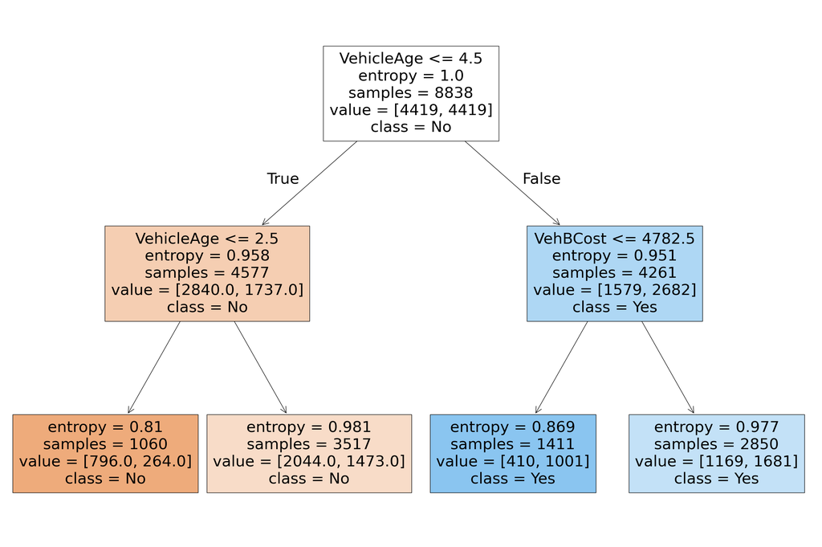

```python
# Plot the tree (0.5 pts)
fig = plt.figure(figsize=(30,20))
tree.plot_tree(model,
               feature_names=list(predictors_train.columns),
               class_names=['No','Yes'],
               filled=True)
```

```python
# Text version of decision tree (0.5 pts)
print(tree.export_text(model, feature_names=list(carAuction.columns)[1:]))
```

```
|--- VehicleAge <= 4.50
|   |--- VehicleAge <= 2.50
|   |   |--- class: No
|   |--- VehicleAge >  2.50
|   |   |--- class: No
|--- VehicleAge >  4.50
|   |--- VehBCost <= 4782.50
|   |   |--- class: Yes
|   |--- VehBCost >  4782.50
|   |   |--- class: Yes
```

```python
# Make predictions on testing data (0.5 pts)
prediction_on_test = model.predict(predictors_test)
```

```
<sklearn.metrics._plot.confusion_matrix.ConfusionMatrixDisplay at 0x7e98b64d22a0>
```

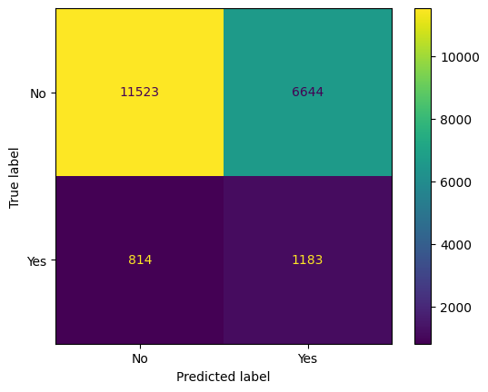

```python
# Examine the evaluation results on testing data: confusion_matrix (0.5 pts)
cm = confusion_matrix(target_test, prediction_on_test)
ConfusionMatrixDisplay(confusion_matrix=cm, display_labels=model.classes_).plot()
```

```python
# Examine the evaluation results on testing data: accuracy, precision, recall, and f1-score (0.5 pts)
print(classification_report(target_test, prediction_on_test))
```

```
              precision    recall  f1-score   support

          No       0.93      0.63      0.76     18167
         Yes       0.15      0.59      0.24      1997

    accuracy                           0.63     20164
   macro avg       0.54      0.61      0.50     20164
weighted avg       0.86      0.63      0.70     20164
```

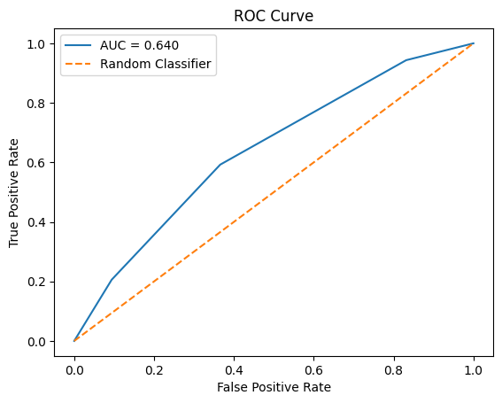

```python
# Encode the target variable before computing ROC/AUC
target_test_bin = target_test.map({'Yes': 1, 'No': 0})

# Get predicted probabilities for the positive class
target_prob = model.predict_proba(predictors_test)[:, 1]

# Compute ROC curve
fpr, tpr, thresholds = roc_curve(target_test_bin, target_prob)

# Compute AUC
auc_score = roc_auc_score(target_test_bin, target_prob)

# Plot ROC curve
plt.figure()
plt.plot(fpr, tpr, label=f"AUC = {auc_score:.3f}")
plt.plot([0, 1], [0, 1], linestyle="--", label="Random Classifier")
plt.xlabel("False Positive Rate")
plt.ylabel("True Positive Rate")
plt.title("ROC Curve")
plt.legend()
plt.show()
```

Q1. Find one path in the tree to a leaf node that is classified to IsBadBuy = 'Yes'. What is this path/rule's misclassification error rate?

```python
import numpy as np
from sklearn.tree import _tree

# --- Find leaf nodes that predict "Yes" ---
tree_ = model.tree_
classes = model.classes_
yes_index = list(classes).index('Yes')

leaf_ids = np.where((tree_.children_left == _tree.TREE_LEAF) &
                    (tree_.children_right == _tree.TREE_LEAF))[0]

yes_leaves = []
for node_id in leaf_ids:
    counts = tree_.value[node_id][0]   # class counts at this leaf
    pred_class = classes[np.argmax(counts)]
    if pred_class == 'Yes':
        yes_leaves.append(node_id)

print("Number of leaves predicting 'Yes':", len(yes_leaves))
leaf = yes_leaves[0]   # pick the first "Yes" leaf (any one is OK)

# --- Compute exact leaf misclassification error rate ---
counts = tree_.value[leaf][0]
n_total = counts.sum()
n_yes = counts[yes_index]
leaf_error = 1 - (n_yes / n_total)

print("Chosen leaf node:", leaf)
print("Class counts [No, Yes] (order = model.classes_):", counts)
print(f"Misclassification error rate at this leaf = {leaf_error:.6f}")

# --- Print the exact rule/path to that leaf ---
# Build the rule by walking from root to leaf using decision path on training data
# We'll find one training sample that ends up in this leaf and trace its decisions.

X_train = predictors_train.values
node_indicator = model.decision_path(X_train)
leaf_id_train = model.apply(X_train)

sample_id = np.where(leaf_id_train == leaf)[0][0]
feature = tree_.feature
threshold = tree_.threshold
feature_names = predictors_train.columns

node_index = node_indicator.indices[
    node_indicator.indptr[sample_id]: node_indicator.indptr[sample_id + 1]
]

print("\nRule path to the 'Yes' leaf:")
for node_id in node_index:
    if node_id == leaf:
        continue
    fname = feature_names[feature[node_id]]
    thresh = threshold[node_id]
    # check direction taken by this sample
    if X_train[sample_id, feature[node_id]] <= thresh:
        print(f" - {fname} <= {thresh:.6f}")
    else:
        print(f" - {fname} >  {thresh:.6f}")
print(" => Predict: Yes")
```

```
Number of leaves predicting 'Yes': 2
Chosen leaf node: 5
Class counts [No, Yes] (order = model.classes_): [0.29057406 0.70942594]
Misclassification error rate at this leaf = 0.290574

Rule path to the 'Yes' leaf:
 - VehicleAge >  4.500000
 - VehBCost <= 4782.500000
 => Predict: Yes
```

Q2. On the testing set, how many bad buy cars are predicted as Not bad buy?

Many bad-buy cars are predicted as not bad-buy, indicating a high false-negative count on the test set.

814 bad buy cars are predicted as Not bad buy on the testing set.

```python
from sklearn.metrics import confusion_matrix

cm = confusion_matrix(target_test, prediction_on_test, labels=model.classes_)
print("Labels order:", model.classes_)
print(cm)

TN, FP, FN, TP = cm.ravel()
print("False Negatives (bad buy predicted as not bad buy) =", FN)
```

```
Labels order: ['No' 'Yes']
[[11523  6644]
 [  814  1183]]
False Negatives (bad buy predicted as not bad buy) = 814
```

Q3. Does the model have a better performance on the majority (IsBadBuy = 'No') or the minority class (IsBadBuy = 'Yes')? why?

The model performs better on the majority class (IsBadBuy = “No”). The recall for the majority class is approximately 63.43%, while the recall for the minority class (IsBadBuy = “Yes”) is about 59.24%. In addition, the model has a very low precision for the minority class (about 15.11%), meaning many cars predicted as bad buys are actually not bad buys. This shows the model favors the majority class and struggles with minority class detection.

Q4. Explain the overal performance of this model. Is this a good model? How can we improve it?

The model performs better on the majority class (IsBadBuy = “No”). The recall for the majority class is approximately 63.43%, while the recall for the minority class (IsBadBuy = “Yes”) is about 59.24%. In addition, the model has a very low precision for the minority class (about 15.11%), meaning many cars predicted as bad buys are actually not bad buys. This shows the model favors the majority class and struggles with minority class detection.

Q5. Build a decision tree model using training data, setting the maximum depth to 3, and assess its performance against the earlier model. Discuss which model you would favor and why.

The depth-3 decision tree performs slightly better than the depth-2 model. While both models achieve the same overall accuracy of 63%, the depth-3 model improves recall for the minority class (IsBadBuy = “Yes”) from 59% to 61%, meaning it correctly identifies more bad-buy vehicles. Additionally, the AUC increases from 0.6395 (depth-2) to 0.6464 (depth-3), indicating better overall classification performance.

Since the depth-3 model improves minority class detection and has a higher AUC without reducing overall accuracy, I would favor the depth-3 model. The slight increase in complexity is justified by the improvement in predictive performance.

```python
import numpy as np
from sklearn.tree import DecisionTreeClassifier
from sklearn.metrics import confusion_matrix, classification_report, roc_auc_score

# --- If you don't already have the depth=2 model built, build it here ---
model_d2 = DecisionTreeClassifier(criterion="entropy", random_state=1, max_depth=2)
model_d2.fit(predictors_train, target_train)

# --- Build depth=3 model ---
model_d3 = DecisionTreeClassifier(criterion="entropy", random_state=1, max_depth=3)
model_d3.fit(predictors_train, target_train)

# --- Predictions ---
pred_d2 = model_d2.predict(predictors_test)
pred_d3 = model_d3.predict(predictors_test)

# --- Confusion matrices ---
labels = model_d2.classes_  # ['No','Yes'] in your case
cm_d2 = confusion_matrix(target_test, pred_d2, labels=labels)
cm_d3 = confusion_matrix(target_test, pred_d3, labels=labels)

print("Labels order:", labels)

print("\nDepth=2 Confusion Matrix:\n", cm_d2)
print("\nDepth=3 Confusion Matrix:\n", cm_d3)

# --- Classification reports ---
print("\nDepth=2 Classification Report:\n", classification_report(target_test, pred_d2))
print("\nDepth=3 Classification Report:\n", classification_report(target_test, pred_d3))

# --- AUC (use probabilities of 'Yes') ---
yes_idx_d2 = list(model_d2.classes_).index("Yes")
yes_idx_d3 = list(model_d3.classes_).index("Yes")

y_test_bin = target_test.map({"No": 0, "Yes": 1})

proba_d2 = model_d2.predict_proba(predictors_test)[:, yes_idx_d2]
proba_d3 = model_d3.predict_proba(predictors_test)[:, yes_idx_d3]

auc_d2 = roc_auc_score(y_test_bin, proba_d2)
auc_d3 = roc_auc_score(y_test_bin, proba_d3)

print(f"\nDepth=2 AUC: {auc_d2:.6f}")
print(f"Depth=3 AUC: {auc_d3:.6f}")

print("\nPreferred model based on AUC:")
print("Depth=3" if auc_d3 > auc_d2 else "Depth=2")
```

```
Labels order: ['No' 'Yes']

Depth=2 Confusion Matrix:
 [[11523  6644]
 [  814  1183]]

Depth=3 Confusion Matrix:
 [[11452  6715]
 [  783  1214]]

Depth=2 Classification Report:
               precision    recall  f1-score   support

          No       0.93      0.63      0.76     18167
         Yes       0.15      0.59      0.24      1997

    accuracy                           0.63     20164
   macro avg       0.54      0.61      0.50     20164
weighted avg       0.86      0.63      0.70     20164


Depth=3 Classification Report:
               precision    recall  f1-score   support

          No       0.94      0.63      0.75     18167
         Yes       0.15      0.61      0.24      1997

    accuracy                           0.63     20164
   macro avg       0.54      0.62      0.50     20164
weighted avg       0.86      0.63      0.70     20164


Depth=2 AUC: 0.639538
Depth=3 AUC: 0.646398

Preferred model based on AUC:
Depth=3
```

Q6. Experiment with the splitting criteria “gini”, “entropy”, and “log_loss”, and vary max_depth from 2 to 30. Which configuration produces the highest AUC?

After testing decision trees with different criteria (gini, entropy, and log_loss) and maximum depths ranging from 2 to 30, the best-performing model achieved an AUC of 0.657346 using:

Criterion: entropy

Max depth: 5

The log_loss criterion with max_depth = 5 produced the same AUC (0.657346), and gini with max_depth = 5 performed almost identically (0.657340). However, entropy with max_depth = 5 is selected as the best configuration since it achieves the highest AUC.

Compared to the earlier depth-2 model (AUC = 0.6395) and depth-3 model (AUC = 0.6464), the depth-5 model shows a noticeable improvement in predictive performance. This indicates that allowing slightly deeper trees helps the model better capture patterns in the data without severe overfitting.

Therefore, the preferred model is the decision tree with criterion = entropy and max_depth = 5, as it provides the highest overall classification performance based on AUC.

```python
import pandas as pd
from sklearn.tree import DecisionTreeClassifier
from sklearn.metrics import roc_auc_score

criteria = ["gini", "entropy", "log_loss"]
depths = range(2, 31)

y_test_bin = target_test.map({"No": 0, "Yes": 1})

rows = []

for crit in criteria:
    for d in depths:
        m = DecisionTreeClassifier(criterion=crit, random_state=1, max_depth=d)
        m.fit(predictors_train, target_train)

        yes_idx = list(m.classes_).index("Yes")
        proba_yes = m.predict_proba(predictors_test)[:, yes_idx]
        auc = roc_auc_score(y_test_bin, proba_yes)

        rows.append({"criterion": crit, "max_depth": d, "AUC": auc})

df_results = pd.DataFrame(rows).sort_values("AUC", ascending=False)

print("Top 10 configurations by AUC:")
print(df_results.head(10).to_string(index=False))

best = df_results.iloc[0]
print("\nBest configuration:")
print(best.to_string())

# (Optional) best per criterion
print("\nBest per criterion:")
print(df_results.sort_values("AUC", ascending=False).groupby("criterion").head(1).to_string(index=False))
```

```
Top 10 configurations by AUC:
criterion  max_depth      AUC
  entropy          5 0.657346
 log_loss          5 0.657346
     gini          5 0.657340
     gini          6 0.653623
 log_loss          4 0.652737
  entropy          4 0.652737
  entropy          6 0.652461
 log_loss          6 0.652461
     gini          4 0.652186
     gini          7 0.647025

Best configuration:
criterion     entropy
max_depth           5
AUC          0.657346

Best per criterion:
criterion  max_depth      AUC
  entropy          5 0.657346
 log_loss          5 0.657346
     gini          5 0.657340
```

```python
!jupyter nbconvert --to html "/content/drive/MyDrive/IS 670/IS670_lab03.ipynb"
```

```
[NbConvertApp] Converting notebook /content/drive/MyDrive/IS 670/IS670_lab03.ipynb to html
[NbConvertApp] WARNING | Alternative text is missing on 3 image(s).
[NbConvertApp] Writing 858490 bytes to /content/drive/MyDrive/IS 670/IS670_lab03.html
```